# Conjoint Analysis

蔡佳泓

2026-03-27

## 1 聯合分析定義與動機

聯合分析是一種用於分析多維度選擇與偏好的實驗設計。

**動機**：傳統實驗通常只能識別整體處理效應（Treatment Effect），但科學理論往往關心特定組成成分的影響。

**方法**：受訪者閱讀由多個屬性（Attributes）組成的輪廓（Profiles），並對其進行選擇、排序或評分。

## 2 潛在結果架構 (Potential Outcomes Framework)

定義聯合分析中的基本單位與變數：

**受訪者**：$i \in \{1, \dots, N\}$

**任務**：$k \in \{1, \dots, K\}$

**輪廓**：$j \in \{1, \dots, J\}$

**屬性**：$l \in \{1, \dots, L\}$，每個屬性有 $D_l$ 個層級。

**刺激 (Treatment)**：$T_{ijk}$ 為一個向量，包含輪廓 $j$ 的所有屬性層級。

### 2.1 核心假設

1. **無外溢效應 (No carryover effect)**：其他任務的輪廓不影響當前任務的評估。
2. **無輪廓順序效應 (No profile-order effect)**：任務內輪廓的出件順序不影響結果。
3. **輪廓隨機化 (Randomization of Profiles)**：屬性必須隨機生成，且所有可能的組合都有正機率被抽中。

## 3 關鍵感興趣量值 (Quantities of Interest)

### 3.1 平均邊際成分效應 (AMCE)

- AMCE 是衡量單一屬性層級對選擇機率（或評分）影響的摘要量值。

$$\bar{\pi}_l(t_1, t_0, p(t)) \equiv E[Y_i(t_1, T_{ijk[-l]}, T_{i[-j]k}) - Y_i(t_0, T_{ijk[-l]}, T_{i[-j]k})]$$

**定義**：在平均分配其他所有屬性層級的情況下，將屬性 $l$ 從基準層級 $t_0$ 變更為 $t_1$ 所產生的效應。

## 4 無參數估計 (Nonparametric Estimation)

- 在屬性完全隨機化的情況下，AMCE 可以透過**簡單均值差 (Difference-in-means)** 或 **線性迴歸** 來估計。
- 屬性獨立性：在聯合分析實驗中，每個輪廓（Profile）的屬性層級是隨機抽取的。這保證了各個屬性之間在統計上是獨立的（彼此不相關），因此我們可以直接觀察單一屬性變動對選擇機率的淨影響，而不會受到其他屬性的干擾。
- 受訪者背景對等：由於屬性組合是隨機分派給不同背景的受訪者，在大量樣本下，受訪者的個人特徵（如性別、政黨傾向）在各個屬性層級之間會達到平衡。
- 交互作用分析：若要分析「受訪者背景」的影響，技術上是透過將「屬性」與「受訪者特徵」進行交互作用 (Interaction)。因為屬性是隨機的，這種交互作用項可以捕捉到不同特徵的群體對特定屬性的偏好差異。

## 5 迴歸模型

- 在聯合分析中，當結果變數 $Y$ 是二元選擇（選或不選，即 0 與 1）時，最常用的估計模型是線性機率模型 (Linear Probability Model, LPM)。
- 雖然邏輯迴歸 (Logit) 也可以處理 0/1 變數，但 Hainmueller et al. (2014) 證明，使用普通最小平方法 (OLS) 估計線性回歸，其係數即直接等於 AMCE。
- 所以聯合分析的理論基礎建立於多項 Logit 模型（Multinomial Logit Model），假設受訪者會選擇效用最大的候選人組合。然而，在實務估計上，依據 Hainmueller et al. (2014) 的建議，採用線性機率模型 (Linear Probability Model, LPM) 進行 OLS 迴歸分析。此種做法的優點在於其係數可直接解讀為平均邊際成分效應 (AMCE)，代表特定屬性層級對候選人選擇機率的淨影響。
- 公式寫成如下形式，表達每個屬性層級相對於基準組的偏離：

$$\text{Choice}_{ijk} = \alpha + \sum_{l=2}^{L} \beta_l \cdot \mathbb{I}(\text{Attribute}_{ijk} = l) + \epsilon_{ijk}$$

- 套用到「年齡」案例，寫法如下：

$$\text{Selection}_{ijk} = \theta_0 + \theta_1 \mathbb{I}(\text{Age}_{ijk} = 75) + \theta_2 \mathbb{I}(\text{Age}_{ijk} = 68) + \dots + \epsilon_{ijk}$$

- $\text{Selection}_{ijk}$：受訪者 $i$ 在第 $j$ 個任務中對於第 $k$ 個候選人輪廓（Profile）的選擇結果（選為 1，不選為 0）。
- $\mathbb{I}(\cdot)$：指示函數。當括號內條件成立時為 1，否則為 0，是「自動虛擬變數」的數學表達方式。
- $\theta_0$：截距項，代表所有屬性都處於**基準層級（Baseline Levels）**時的平均選擇機率。
- $\theta_1, \theta_2$：即為 AMCE。它們代表當候選人年齡從基準組（例如 45 歲）變更為 75 歲或 68 歲時，選擇機率的淨變化量。
- 係數 $\hat{\theta}_1, \hat{\theta}_2$ 等估計值即代表該屬性層級相對於基準組（Reference Group）的平均邊際成分效應（AMCE）。由於採用線性機率模型（LPM）進行估計，該係數可直接詮釋為：在其他屬性特徵隨機分佈的條件下，候選人具備該特徵相較於基準特徵時，受訪者選擇機率的百分點變化。
- 在 R 中，可以使用 `lm()` 函數或專門的 `cregg` / `conjoint` 套件進行估計。

### 5.1 多項式迴歸模型

- 剛剛提到，聯合分析的基礎是多項 Logit 模型（Multinomial Logit Model），又稱為效用模型。 假設有 $L$ 個屬性，每個屬性 $l$ 有不同的層級，模型如下：
- $$U_{ni} = \sum_{l=1}^{L} \sum_{k=1}^{K_l} \beta_{lk} X_{nilk} + \epsilon_{ni}$$

其中：

- $U_{ni}$ 是受訪者 $n$ 對於方案 $i$ 的效用（Utility）。
- $\beta_{lk}$ 是屬性 $l$ 在第 $k$ 個層級的係數（Part-worth utilities）。
- $X_{nilk}$ 是一個虛擬變數（Dummy variable），若方案 $i$ 的屬性 $l$ 處於第 $k$ 個層級則為 1，否則為 0。
- $\epsilon_{ni}$ 為隨機誤差項。
- 受訪者選擇方案 $i$ 的機率 $P_{ni}$ 可表示為：

$$P_{ni} = \frac{\exp(V_{ni})}{\sum_{j \in C} \exp(V_{nj})}$$

- 公式中的 $V_{ni}$ 代表受訪者 $n$ 認知到方案 $i$ 的效用（Utility）。
- $V_{ni}$ 是由候選人的屬性（例如：性別、政見、黨籍）加總而成的。如果一個候選人具備「溝通式民主」且是「同黨籍」，他的 $V_{ni}$ 分數就會比較高。
- 最後，我們可以計算所有樣本在特定情境下的**平均選擇機率**（Average Choice Probability）。

## 6 實例分析

**候選人實驗**：包含宗教、教育、專業、收入、種族、年齡、軍旅經歷、性別等 8 個屬性。

**移民實驗**：包含教育、工作經驗、原籍國、申請理由等 9 個屬性，並加入特定限制（如：高技術職業必須有兩年以上大學學歷）。

## 7 《Communicative Democracy and Voter Choice: Evidence From a Conjoint Analysis in Taiwan》（Tsai and Wang, 2024）

研究選民是否偏好那些強調「透明溝通、主動參與和有意義對話」（溝通式民主）的候選人，而非僅強調「少數服從多數」（多數決原則）的候選人。

### 7.1 研究方法

採用**聯合分析（Conjoint Analysis）**實驗，邀請受訪者在不同屬性組合（如政見原則、年齡、性別、黨派、學歷等）的候選人中進行選擇。

### 7.2 主要發現：

- 偏好溝通：選民顯著偏好支持溝通式民主原則的候選人。
- 包容性價值：這反映了選民渴望政策能反映多元觀點，而不僅是強勢多數的意志。
- 跨黨派一致性：這種對溝通價值的追求在不同政黨支持者之間具有一定的普遍性。

## 8 Data

- 在分析資料之前，先觀察資料結構。

### 8.1 Original Data

- 原始資料中，每個受訪者有一組人口背景跟其他題目的變數，而有兩個輪廓的資料。例如，候選人的性別有兩個欄位(S1, T1)、黨籍有兩個欄位等等。

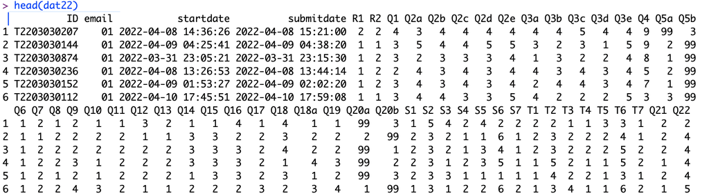

Figure 1: Original Data Structure

- 從資料結構可以看出，在實驗設計中，受訪者每回答一題（一個選擇情境），畫面上會同時出現兩個候選人（Profile 1 和 Profile 2）。
- 雖然受訪者只有 1200 多人，但因為每個人都同時評估了「左邊」跟「右邊」的候選人，所以Profile 1 和 Profile 2 分別有 1200 多個0與1。

### 8.2 Reshaped Data

- 可以用Stata轉換為長資料。

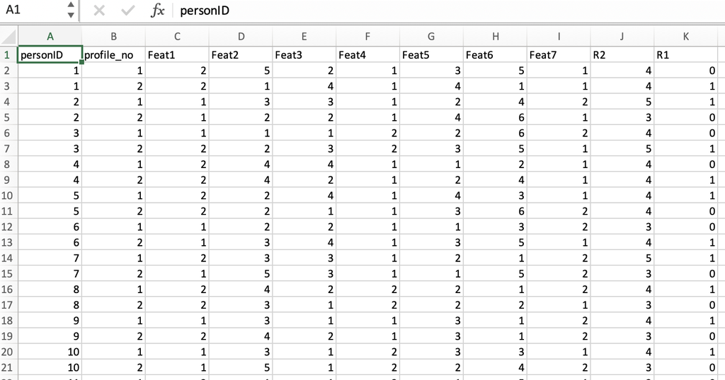

Figure 2: Reshaped Data by Stata

- 把原始資料分為兩筆資料，分別有一個輪廓的屬性，經過合併之後，觀察值變成兩倍，因為每個受訪者變成兩筆資料，也就是每個輪廓各佔一列。檢驗資料是否正確。

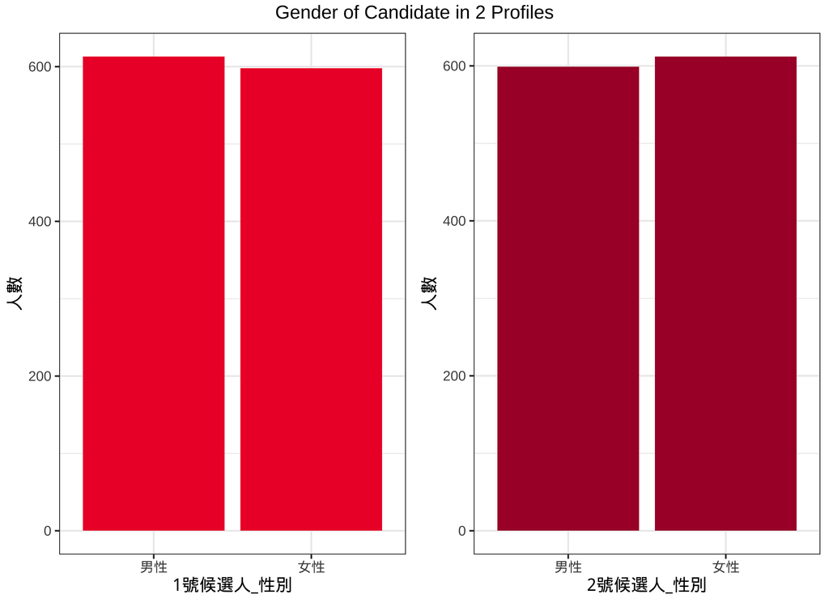

Figure 3: Candidate Gender

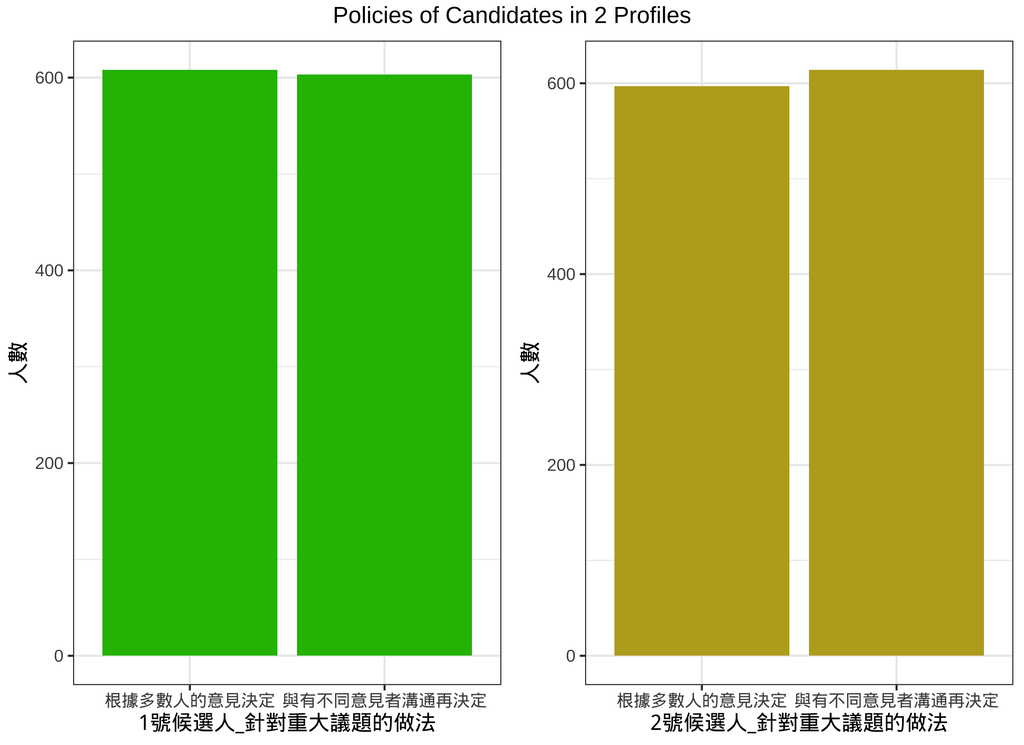

Figure 4: Communicative or Majoritarian

## 9 Descriptive Statistics

### 9.1 Candidate Attributes

#### 9.1.1 Frequencies of Attributes

```r
 key_vars <- c('Incumbent','Gender','Age','Education','Occupation','Party','Policy','profile')
 df_labeled <- mydata %>%
   select(any_of(key_vars)) %>%
   as_label()
 print(freq(df_labeled, plain.ascii = FALSE, style = "rmarkdown"))
```

### 9.2 df_labeled$Incumbent

**Type:** Factor

|  | Freq | % Valid | % Valid Cum. | % Total | % Total Cum. |
| --- | --- | --- | --- | --- | --- |
| **Challenger** | 1195 | 49.34 | 49.34 | 49.34 | 49.34 |
| **Incumbent** | 1227 | 50.66 | 100.00 | 50.66 | 100.00 |
| **<NA>** | 0 |  |  | 0.00 | 100.00 |
| **Total** | 2422 | 100.00 | 100.00 | 100.00 | 100.00 |

#### 9.2.1 df_labeled$Gender

**Type:** Factor

|  | Freq | % Valid | % Valid Cum. | % Total | % Total Cum. |
| --- | --- | --- | --- | --- | --- |
| **Female** | 1210 | 49.96 | 49.96 | 49.96 | 49.96 |
| **Male** | 1212 | 50.04 | 100.00 | 50.04 | 100.00 |
| **<NA>** | 0 |  |  | 0.00 | 100.00 |
| **Total** | 2422 | 100.00 | 100.00 | 100.00 | 100.00 |

### 9.3 df_labeled$Age

**Type:** Factor

|  | Freq | % Valid | % Valid Cum. | % Total | % Total Cum. |
| --- | --- | --- | --- | --- | --- |
| **64 years old** | 612 | 25.27 | 25.27 | 25.27 | 25.27 |
| **51 years old** | 582 | 24.03 | 49.30 | 24.03 | 49.30 |
| **46 years old** | 647 | 26.71 | 76.01 | 26.71 | 76.01 |
| **38 years old** | 581 | 23.99 | 100.00 | 23.99 | 100.00 |
| **<NA>** | 0 |  |  | 0.00 | 100.00 |
| **Total** | 2422 | 100.00 | 100.00 | 100.00 | 100.00 |

#### 9.3.1 df_labeled$Education

**Type:** Factor

|  | Freq | % Valid | % Valid Cum. | % Total | % Total Cum. |
| --- | --- | --- | --- | --- | --- |
| **Graduate school** | 611 | 25.23 | 25.23 | 25.23 | 25.23 |
| **University** | 582 | 24.03 | 49.26 | 24.03 | 49.26 |
| **College** | 592 | 24.44 | 73.70 | 24.44 | 73.70 |
| **High school** | 637 | 26.30 | 100.00 | 26.30 | 100.00 |
| **<NA>** | 0 |  |  | 0.00 | 100.00 |
| **Total** | 2422 | 100.00 | 100.00 | 100.00 | 100.00 |

#### 9.3.2 df_labeled$Occupation

**Type:** Factor

|  | Freq | % Valid | % Valid Cum. | % Total | % Total Cum. |
| --- | --- | --- | --- | --- | --- |
| **Farmer** | 392 | 16.18 | 16.18 | 16.18 | 16.18 |
| **Labor** | 423 | 17.46 | 33.65 | 17.46 | 33.65 |
| **Business** | 384 | 15.85 | 49.50 | 15.85 | 49.50 |
| **Teacher** | 383 | 15.81 | 65.32 | 15.81 | 65.32 |
| **Civil servant** | 396 | 16.35 | 81.67 | 16.35 | 81.67 |
| **Military** | 444 | 18.33 | 100.00 | 18.33 | 100.00 |
| **<NA>** | 0 |  |  | 0.00 | 100.00 |
| **Total** | 2422 | 100.00 | 100.00 | 100.00 | 100.00 |

#### 9.3.3 df_labeled$Party

**Type:** Factor

|  | Freq | % Valid | % Valid Cum. | % Total | % Total Cum. |
| --- | --- | --- | --- | --- | --- |
| **KMT** | 482 | 19.90 | 19.90 | 19.90 | 19.90 |
| **DPP** | 494 | 20.40 | 40.30 | 20.40 | 40.30 |
| **TPP** | 464 | 19.16 | 59.45 | 19.16 | 59.45 |
| **NPP** | 477 | 19.69 | 79.15 | 19.69 | 79.15 |
| **Independent** | 505 | 20.85 | 100.00 | 20.85 | 100.00 |
| **<NA>** | 0 |  |  | 0.00 | 100.00 |
| **Total** | 2422 | 100.00 | 100.00 | 100.00 | 100.00 |

#### 9.3.4 df_labeled$Policy

**Type:** Factor

|  | Freq | % Valid | % Valid Cum. | % Total | % Total Cum. |
| --- | --- | --- | --- | --- | --- |
| **Communicative** | 1217 | 50.25 | 50.25 | 50.25 | 50.25 |
| **Majority** | 1205 | 49.75 | 100.00 | 49.75 | 100.00 |
| **<NA>** | 0 |  |  | 0.00 | 100.00 |
| **Total** | 2422 | 100.00 | 100.00 | 100.00 | 100.00 |

#### 9.3.5 df_labeled$profile

**Type:** Factor

|  | Freq | % Valid | % Valid Cum. | % Total | % Total Cum. |
| --- | --- | --- | --- | --- | --- |
| **1** | 1211 | 50.00 | 50.00 | 50.00 | 50.00 |
| **2** | 1211 | 50.00 | 100.00 | 50.00 | 100.00 |
| **<NA>** | 0 |  |  | 0.00 | 100.00 |
| **Total** | 2422 | 100.00 | 100.00 | 100.00 | 100.00 |

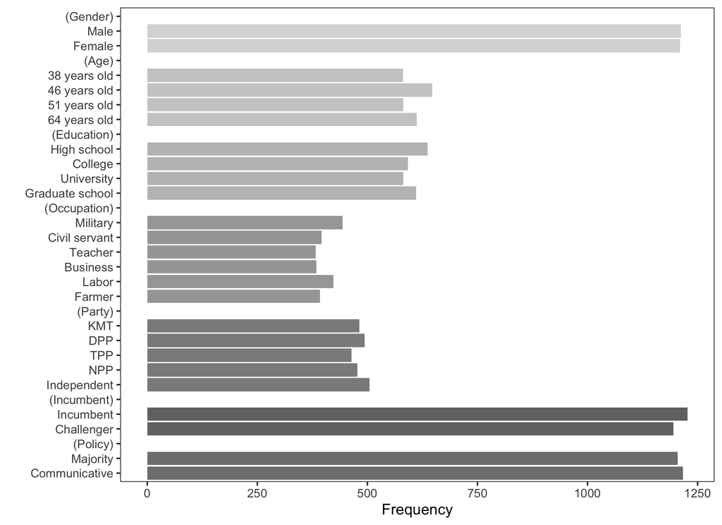

Figure 5: Frequencies of Candidate Attibutes

#### 9.3.6 Respondent’s Variables

- 受訪者除了人口背景資料外，還有一組測量同理心的變數，分佈為：

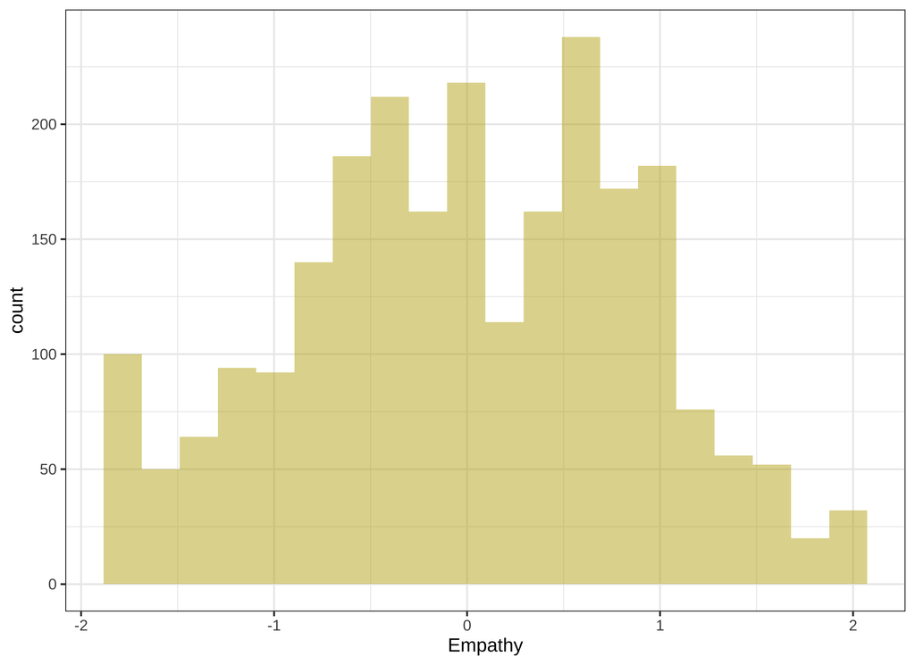

Figure 6: Distribution of Empathy

## 10 Main Results

### 10.1 Figure 1

- 在聯合分析的結果圖表中，X 軸標示為 “Change in Pr(Vote for Candidate)”（候選人被選中機率的變化）， 代表的是 AMCE (Average Marginal Component Effect)。其技術原因與意涵如下：
1. 衡量「邊際影響力」聯合分析的目的是測量「當某個屬性從基準值改變時，會增加或減少多少勝算」。0 軸（基準線）：圖中會有一條垂直虛線在 0 的位置，代表該屬性的「基準層級」（Baseline）。正值（>0）：表示若候選人具備該特徵，其被選中的機率會比基準組「增加」多少（例如 0.1 代表增加 10% 的機率）。負值（<0）：表示該特徵會「降低」選民選擇該候選人的機率。
2. 這類分析通常使用線性機率模型，在該模型下，迴歸係數（$\beta$）可以直接解釋為機率的絕對變化。例如，Figure 1 中顯示「溝通式民主」相對於「多數決」的係數落在正值區間，代表將政策原則從多數決（基準）轉換為溝通式民主時，受訪者選擇該候選人的機率預期變化量。
3. 易於解釋與比較使用 “Change in Pr” 而不是 Log-odds（邏輯迴歸係數）的好處在於直觀。例如：相較於一個 50 歲的候選人，一個 30 歲的候選人會讓選票機率「增加幾百分點」，這讓不同屬性（如年齡 vs. 政策原則）之間的影響力大小可以直接進行比較。

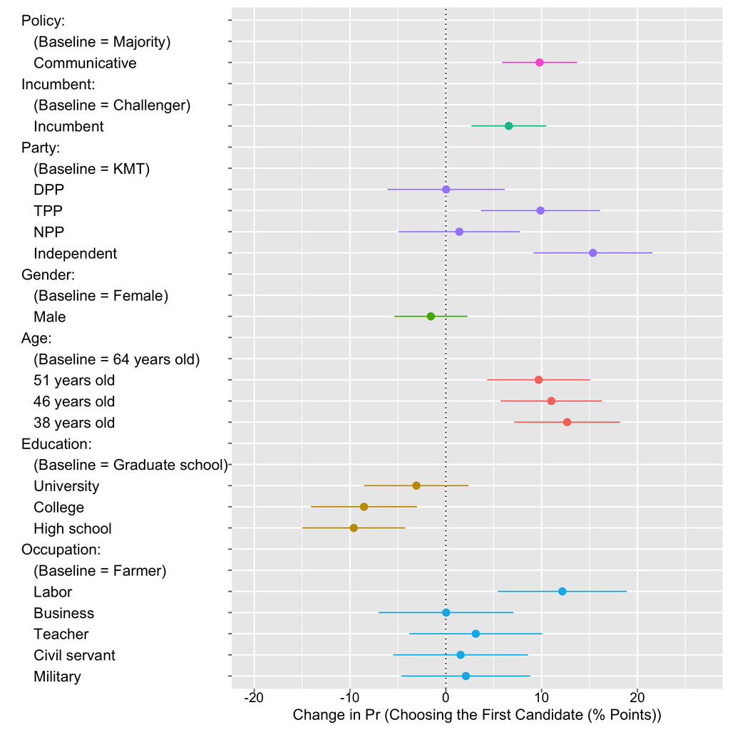

Figure 7: Estimated AMCE

```r
baselines <- list()
baselines$Policy <- "Majority"
res1 <- cjoint::amce(data=mydata, choice ~ `Gender` + `Age` + `Education` +
               `Occupation` + `Party` + `Incumbent` +  `Policy`,
             respondent.id='person', baselines=baselines,
             cluster = T, na.ignore = T)
plot(res1,group.order = c("Policy", "Incumbent", "Party","Gender",
                          "Age","Education","Occupation"),
  xlab = "Change in Pr (Choosing the First Candidate (% Points))",
  breaks=c(-.2, -.1, 0, .1, .2), labels=c("-20","-10","0","10","20"),
  text.size=13)
```

- 在做 Conjoint 時，第一個 level 就會被自動當作 Dummy 轉換中的基準點。R 語言的性質與聯合分析套件的自動化處理處理了虛擬變數。

### 10.2 Figure 2

- 按照受訪者的政黨認同分成泛藍、泛綠、民眾黨、無政黨認同，進行分析。
- 可以發現，泛綠、民眾黨、無政黨認同者支持溝通式民主，符合假設。

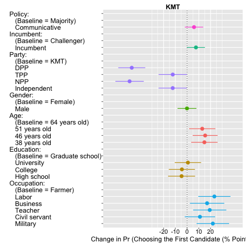

Figure 8: Estimated AMCE, KMT

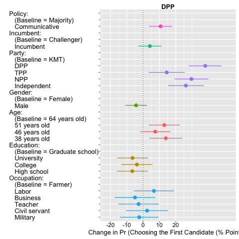

Figure 9: Estimated AMCE, DPP

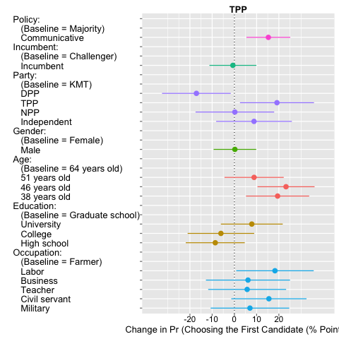

Figure 10: Estimated AMCE, TPP

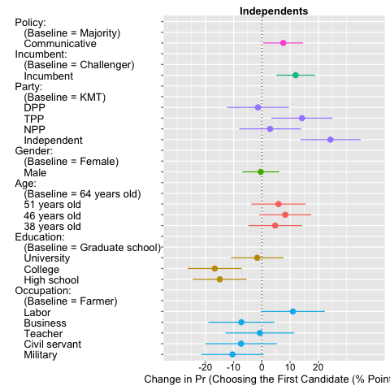

Figure 11: Estimated AMCE, Non-Partisans

```r
data_blue <- subset(mydata, PartyID == "Pan-Blue")
baselines$Policy <- "Majority"
res_blue <- cjoint::amce(data = data_blue,
                        choice ~ Gender + Age + Education + Occupation + Party + Incumbent + Policy,
                        respondent.id = 'person', cluster = TRUE, na.ignore = TRUE, baselines=baselines)
png(filename="/Users/Chiahung/Dropbox/Conjoint_Soochow/Fig/Figure2_ByParty1.png")
plot(res_blue, group.order = c("Policy", "Incumbent", "Party","Gender",
                          "Age","Education","Occupation"),
  xlab = "Change in Pr (Choosing the First Candidate (% Points))",
  breaks=c(-.2, -.1, 0, .1, .2), labels=c("-20","-10","0","10","20"),
  text.size=13, main = 'KMT')
dev.off()
```

## 11 Robustness Checks

### 11.1 Profile Order Effect

- 每個受訪者都同時評估了「左邊」跟「右邊」的候選人，所以我們的分析是要確定輪廓1跟輪廓2這兩筆資料中，決定是否選擇該候選人的因素一樣。
- 我們可以分別對這兩筆資料分別進行Conjoint analysis，來確認候選人的屬性特徵呈現在左側或右側，並不會系統性地改變受訪者的投票選擇，確保了實驗估計的有效性，也就是沒有輪廓順位效應（Profile Order Effect）。

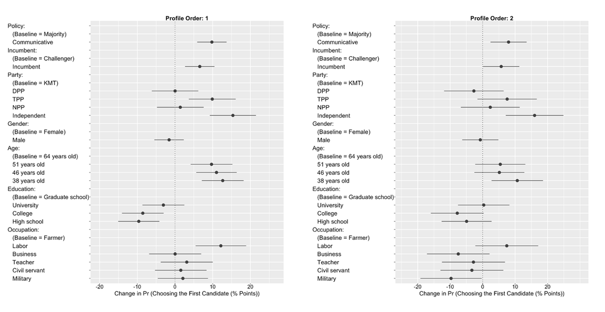

Figure 12: Profile Order Effect

```r
mydata$profileorder<-as.numeric(mydata$profile)
baselines <- list()
baselines$Policy <- "Majority"
mydata.p1 <- mydata %>% dplyr::filter(profileorder == 1)
mydata.p2 <- mydata %>% dplyr::filter(profileorder == 2)

resp1 <- cjoint::amce(data=mydata, choice ~ `Gender` + `Age` + `Education` +
      `Occupation` + `Party` + `Incumbent` +  `Policy`,
             respondent.id='person', baselines=baselines,
             cluster = F, na.ignore = T)

resp2 <- cjoint::amce(data=mydata.p2, choice ~ `Gender` + `Age` + `Education` +
                        `Occupation` + `Party` + `Incumbent` +  `Policy`,
                      respondent.id='person', baselines=baselines,
                      cluster = F, na.ignore = T)
png('./Fig/fig_oriprofile1.png', height = 2200, width = 2200, res = 250)
plot.amce(resp1,
  xlab = "Change in Pr (Choosing the First Candidate (% Points))",
    breaks=c(-.2, -.1, 0, .1, .2), labels=c("-20","-10","0","10","20"),
    text.size=13, group.order = c("Policy", "Incumbent", "Party","Gender",
              "Age","Education","Occupation"), colors = 'gray25',
  labs(title = 'Profile Order: 1'))
dev.off()

png('./Fig/fig_oriprofile2.png', height = 2200, width = 2200, res = 250)
plot.amce(resp2,
       xlab = "Change in Pr (Choosing the First Candidate (% Points))",
        breaks=c(-.2, -.1, 0, .1, .2), labels=c("-20","-10","0","10","20"),
          text.size=13, group.order = c("Policy", "Incumbent", "Party","Gender",
           "Age","Education","Occupation"), colors = 'gray25',
       labs(title = 'Profile Order: 2'))
dev.off()
```

### 11.2 Assignment of Candidate Profile Effect

- 如果候選人特質是隨機分配，則候選人屬性與受訪者特徵（共變量）之間不應有相關性。例如：不同的教育程度的受訪者，對於這兩個候選人的評分應該沒有顯著差異。
- 只有當屬性分配完全隨機時，我們計算出來的 AMCE（平均邊際成分效應）才能被解釋為因果影響，而不是因為特定族群看特定輪廓所導致的巧合。
- 可以將「受訪者特徵」（如年齡、教育程度、政黨認同）當作自變數，去迴歸預測「候選人屬性」（如候選人是否支持溝通式民主）。當屬性分配完全隨機時，所有的係數應該都接近 0，且其 95% 信賴區間應該包含 0（不顯著）。

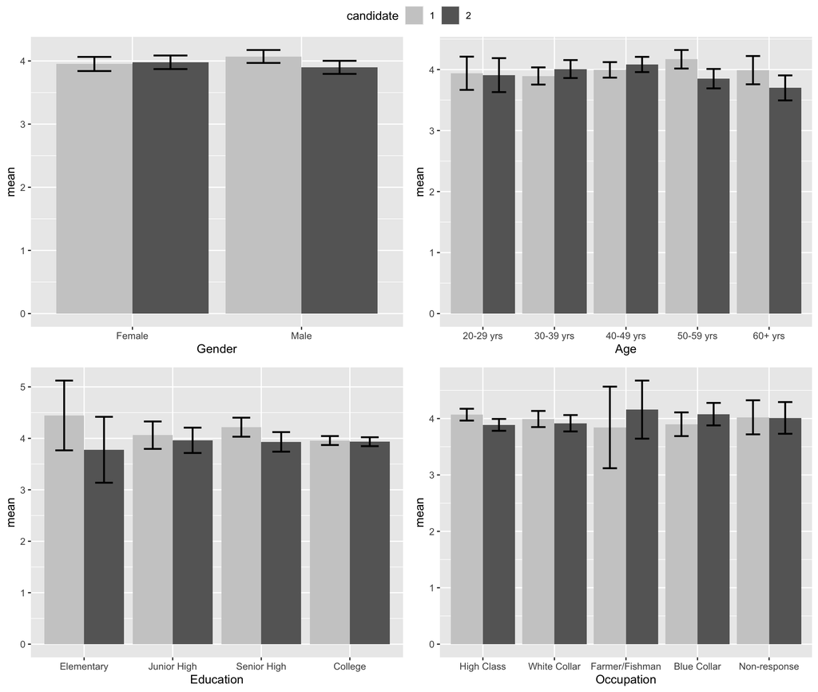

Figure 13: Assignment of Candidate Profile Effect

```r
dat22.select<-data.frame(candidate1=dat22$Q22,
                       candidate2=dat22$Q23,
                       AGE=dat22$AGE, EDU=dat22$EDU,
                       OCCU=dat22$CAREER, L=dat22$resgender)
dat22.select$L <- as.factor(dat22.select$L)
#dat22.select$L <- as.numeric(dat22.select$L)
# Calculates mean, sd, se and IC
library(tidyverse); library(dplyr)
my_sum1 <- dat22.select %>%
  dplyr::group_by(L) %>%
  dplyr::summarise(
    n=n(),
    mean = mean(candidate1),
    sd = sd(candidate1)
  ) %>%
  dplyr::mutate(se=sd/sqrt(n))  %>%
  dplyr::mutate(candidate=1)  %>%
  dplyr::mutate( ic=se * qt((1-0.05)/2 + .5, n-1))

my_sum2 <- dat22.select %>%
  dplyr::group_by(L) %>%
  dplyr::summarise(
    n=n(),
    mean = mean(candidate2),
    sd = sd(candidate2)
  ) %>%
  mutate(se=sd/sqrt(n))  %>%
  mutate(candidate=2)  %>%
  dplyr::mutate( ic=se * qt((1-0.05)/2 + .5, n-1))

my_sum12 <- data.frame(rbind(my_sum1, my_sum2))

my_sum12 <- my_sum12 %>%
  mutate_at(vars(candidate), factor) %>%
  mutate_at(vars(L), as.numeric)

my_sum12$Gender[my_sum12$L == 1]<-'Female'
my_sum12$Gender[my_sum12$L == 2]<-'Male'

my_sum12$Gender=factor(my_sum12$Gender,
                    levels=c('Female','Male'))

gender1<-ggplot(my_sum12, aes(x= Gender, y= mean, fill= candidate)) +
  geom_bar( stat="identity",
            position=position_dodge() ) +
  scale_fill_manual(values=c('gray80', 'gray40')) +
  geom_errorbar( aes(ymin= mean - ic, ymax= mean + ic),
                 width=0.4, colour="black",  size= 0.8,
                 position=position_dodge(.9))
```

## 12 Comparing LPM and Logit Models

- 根據 Hainmueller et al. (2014) 的理論：
1. 屬性獨立性：因為 Conjoint 的屬性是隨機分派的，屬性之間沒有相關性（相互獨立），這減少了函數形式（線性 vs S型曲線）對估計值的影響。
2. 機率分佈在中段：Logit 曲線與 LPM 直線最大的差別在於極端值（機率接近 0 或 1 時）。但在 Conjoint 實驗中，受訪者的選擇機率通常落在 $0.2 \sim 0.8$ 之間（中間段），在這個範圍內，Logit 曲線看起來幾乎就是一條直線。
- 所以LPM (OLS)：係數 $\hat{\beta}$ 會等於「平均邊際效應」。
- LPM (OLS)：係數 $\hat{\beta}$ 本身就是機率的變化量（例如 $0.05$ 代表 $+5\%$）。Logit：原始係數是 Log-Odds，計算 「平均邊際效應」(Average Marginal Effects, AME)，是 Logit 模型預測的機率變化。

### 12.1 LPM

```r
model_lpm <- lm(choice ~ Gender + Party + Policy, data = mydata)
```

|  | *Dependent variable:* |
| --- | --- |
|  | choice |
| GenderMale | -0.013 |
|  | (0.020) |
| PartyDPP | 0.001 |
|  | (0.032) |
| PartyTPP | 0.100*** |
|  | (0.032) |
| PartyNPP | 0.012 |
|  | (0.032) |
| PartyIndependent | 0.147*** |
|  | (0.031) |
| PolicyMajority | -0.098*** |
|  | (0.020) |
| Constant | 0.503*** |
|  | (0.027) |
| Observations | 2,422 |
| R<sup>2</sup> | 0.025 |
| Adjusted R<sup>2</sup> | 0.023 |
| Residual Std. Error | 0.494 (df = 2415) |
| F Statistic | 10.330*** (df = 6; 2415) |
| *Note:* | p<0.1; p<0.05; p<0.01 |

### 12.2 AME from Logit model

```r
library(margins)
model_logit <- glm(choice ~ Gender + Party + Policy, data = mydata, family = binomial(link = "logit"))
# 計算 Logit 的平均邊際效應 (AME)
logit_ame <- margins(model_logit)
```

| Statistic | N | Mean | St. Dev. | Min | Max |
| --- | --- | --- | --- | --- | --- |
| dydx_GenderMale | 2,422 | -0.013 | 0.0003 | -0.013 | -0.012 |
| dydx_PartyDPP | 2,422 | 0.001 | 0.00002 | 0.001 | 0.001 |
| dydx_PartyTPP | 2,422 | 0.100 | 0.0003 | 0.099 | 0.100 |
| dydx_PartyNPP | 2,422 | 0.012 | 0.0002 | 0.012 | 0.012 |
| dydx_PartyIndependent | 2,422 | 0.147 | 0.001 | 0.145 | 0.148 |
| dydx_PolicyMajority | 2,422 | -0.098 | 0.001 | -0.099 | -0.095 |
| _at_number | 2,422 | 1.000 | 0.000 | 1 | 1 |